# Peer Graded Assignment: Week 4 Machine Learning

Nicole Lakens

4 oktober 2019

# Description of the project

## Background

Using devices such as Jawbone Up, Nike FuelBand, and Fitbit it is now possible to collect a large amount of data about personal activity relatively inexpensively. These type of devices are part of the quantified self movement – a group of enthusiasts who take measurements about themselves regularly to improve their health, to find patterns in their behavior, or because they are tech geeks. One thing that people regularly do is quantify how much of a particular activity they do, but they rarely quantify how well they do it. In this project, your goal will be to use data from accelerometers on the belt, forearm, arm, and dumbell of 6 participants. They were asked to perform barbell lifts correctly and incorrectly in 5 different ways. More information is available from the website here: http://groupware.les.inf.puc-rio.br/har (see the section on the Weight Lifting Exercise Dataset). The data for this project come from this source: http://web.archive.org/web/20161224072740/http:/groupware.les.inf.puc-rio.br/har.

## What I should submit

The goal of my project is to predict the manner in which they did the exercise. This is the “classe” variable in the training set. We can use any of the other variables to predict with. I should create a report describing how I built the model, how I used cross validation, what I think the expected out of sample error is, and why I made the choices I did. I will also use my prediction model to predict 20 different test cases.

# Building the model

## Used packages

First, I make sure the packages that I will be using are active.

```r
library(RANN)
library(dplyr)
library(caret)
```

## Reading in the data and check how it looks

I did this twice because I found out that some variables had text in it like “#DIV/0”. So I added the “na.strings”-syntax to the read.csv.

```r
training <- read.csv("C:/Users/nlake/Downloads/pml-training.csv", na.strings = c("NA", "", "#DIV/0!"))
testing <- read.csv("C:/Users/nlake/Downloads/pml-testing.csv", na.strings = c("NA", "", "#DIV/0!"))

summary(training)
```

```
##        X            user_name    raw_timestamp_part_1 raw_timestamp_part_2
##  Min.   :    1   adelmo  :3892   Min.   :1.322e+09    Min.   :   294
##  1st Qu.: 4906   carlitos:3112   1st Qu.:1.323e+09    1st Qu.:252912
##  Median : 9812   charles :3536   Median :1.323e+09    Median :496380
##  Mean   : 9812   eurico  :3070   Mean   :1.323e+09    Mean   :500656
##  3rd Qu.:14717   jeremy  :3402   3rd Qu.:1.323e+09    3rd Qu.:751891
##  Max.   :19622   pedro   :2610   Max.   :1.323e+09    Max.   :998801
##
##           cvtd_timestamp  new_window    num_window      roll_belt
##  28/11/2011 14:14: 1498   no :19216   Min.   :  1.0   Min.   :-28.90
##  05/12/2011 11:24: 1497   yes:  406   1st Qu.:222.0   1st Qu.:  1.10
##  30/11/2011 17:11: 1440               Median :424.0   Median :113.00
##  05/12/2011 11:25: 1425               Mean   :430.6   Mean   : 64.41
##  02/12/2011 14:57: 1380               3rd Qu.:644.0   3rd Qu.:123.00
##  02/12/2011 13:34: 1375               Max.   :864.0   Max.   :162.00
##  (Other)         :11007
##    pitch_belt          yaw_belt       total_accel_belt kurtosis_roll_belt
##  Min.   :-55.8000   Min.   :-180.00   Min.   : 0.00    Min.   :-2.121
##  1st Qu.:  1.7600   1st Qu.: -88.30   1st Qu.: 3.00    1st Qu.:-1.329
##  Median :  5.2800   Median : -13.00   Median :17.00    Median :-0.899
##  Mean   :  0.3053   Mean   : -11.21   Mean   :11.31    Mean   :-0.220
##  3rd Qu.: 14.9000   3rd Qu.:  12.90   3rd Qu.:18.00    3rd Qu.:-0.219
##  Max.   : 60.3000   Max.   : 179.00   Max.   :29.00    Max.   :33.000
##                                                        NA's   :19226
##  kurtosis_picth_belt kurtosis_yaw_belt skewness_roll_belt
##  Min.   :-2.190      Mode:logical      Min.   :-5.745
##  1st Qu.:-1.107      NA's:19622        1st Qu.:-0.444
##  Median :-0.151                        Median : 0.000
##  Mean   : 4.334                        Mean   :-0.026
##  3rd Qu.: 3.178                        3rd Qu.: 0.417
##  Max.   :58.000                        Max.   : 3.595
##  NA's   :19248                         NA's   :19225
##  skewness_roll_belt.1 skewness_yaw_belt max_roll_belt     max_picth_belt
##  Min.   :-7.616       Mode:logical      Min.   :-94.300   Min.   : 3.00
##  1st Qu.:-1.114       NA's:19622        1st Qu.:-88.000   1st Qu.: 5.00
##  Median :-0.068                         Median : -5.100   Median :18.00
##  Mean   :-0.296                         Mean   : -6.667   Mean   :12.92
##  3rd Qu.: 0.661                         3rd Qu.: 18.500   3rd Qu.:19.00
##  Max.   : 7.348                         Max.   :180.000   Max.   :30.00
##  NA's   :19248                          NA's   :19216     NA's   :19216
```

[output cut: 313 more lines]

```
##  Min.   :-446.00   Min.   :-1280.0   Min.   :-896.0   Min.   :-973.0
##  1st Qu.:-182.00   1st Qu.: -616.0   1st Qu.:   2.0   1st Qu.: 191.0
##  Median : -39.00   Median : -378.0   Median : 591.0   Median : 511.0
##  Mean   : -55.29   Mean   : -312.6   Mean   : 380.1   Mean   : 393.6
##  3rd Qu.:  26.00   3rd Qu.:  -73.0   3rd Qu.: 737.0   3rd Qu.: 653.0
##  Max.   : 291.00   Max.   :  672.0   Max.   :1480.0   Max.   :1090.0
##
##  classe
##  A:5580
##  B:3797
##  C:3422
##  D:3216
##  E:3607
##
##
```

```r
head(training)
```

```
##   X user_name raw_timestamp_part_1 raw_timestamp_part_2   cvtd_timestamp
## 1 1  carlitos           1323084231               788290 05/12/2011 11:23
## 2 2  carlitos           1323084231               808298 05/12/2011 11:23
## 3 3  carlitos           1323084231               820366 05/12/2011 11:23
## 4 4  carlitos           1323084232               120339 05/12/2011 11:23
## 5 5  carlitos           1323084232               196328 05/12/2011 11:23
## 6 6  carlitos           1323084232               304277 05/12/2011 11:23
##   new_window num_window roll_belt pitch_belt yaw_belt total_accel_belt
## 1         no         11      1.41       8.07    -94.4                3
## 2         no         11      1.41       8.07    -94.4                3
## 3         no         11      1.42       8.07    -94.4                3
## 4         no         12      1.48       8.05    -94.4                3
## 5         no         12      1.48       8.07    -94.4                3
## 6         no         12      1.45       8.06    -94.4                3
##   kurtosis_roll_belt kurtosis_picth_belt kurtosis_yaw_belt
```

[output cut: 265 more lines]

```r
table(training$classe)
```

```
##
##    A    B    C    D    E
## 5580 3797 3422 3216 3607
```

## Deleting variables

Column X is a row indicator; let’s delete this one. User name cannot be a predictor in this model; let’s delete the user name. A timestamp does not look like a variable that can predict a movement; let’s delete the variables that we will not use.

```r
training$X <- NULL
testing$X <- NULL

training$user_name <- NULL
testing$user_name <- NULL

training$raw_timestamp_part_1 <- NULL
testing$raw_timestamp_part_1 <- NULL


training$raw_timestamp_part_2 <- NULL
testing$raw_timestamp_part_2 <- NULL


training$cvtd_timestamp <- NULL
testing$cvtd_timestamp <- NULL


training$new_window <- NULL
testing$new_window <- NULL


training$num_window <- NULL
testing$num_window <- NULL
```

## Splitting the trainingset

Split the trainingset in a trainingset and validationset, so that we can calculate the out of sample errorrate.

```r
set.seed(800)
partit <- createDataPartition(y=training$classe, p=0.75, list=FALSE)
training_part <- training[partit, ]
validation_part <- training[-partit, ]
```

## Check the distribution of the var to be predicted

Create a table and a plot so we can see how the classe-variable is distributed.

```r
table(training_part$classe)
```

```
##
##    A    B    C    D    E
## 4185 2848 2567 2412 2706
```

```r
table(training_part$classe)/nrow(training_part)
```

```
##
##         A         B         C         D         E
## 0.2843457 0.1935046 0.1744123 0.1638810 0.1838565
```

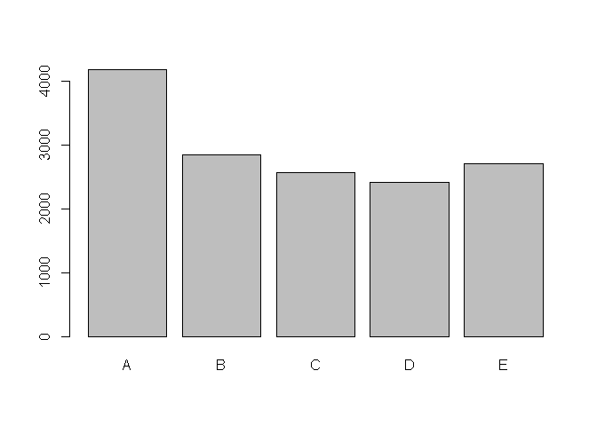

```r
plot(training_part$classe)
```

## Imputation and (near) zero variance variables

Check if NA’s are present in the dataset.

```r
table(is.na(training_part))
```

```
##
##   FALSE    TRUE
##  806804 1445050
```

Yes, there are NA’s, so we have to impute the NA’s. I am using the preprocess function from Caret to impute the NA’s. I will also remove zero variance and near zero variance columns.

```r
nzv <- nearZeroVar(training_part)
nzv
```

```
##  [1]   7  10  19  44  45  46  47  48  49  50  51  52  68  71  72  74  75
## [18]  82  85  94 120 123 124 127 132 135 136 137 138 139 140 141 142 143
```

```r
training_part <- training_part[,-nzv]
validation_part <- validation_part[,-nzv]
testing_part <- testing[,-nzv]

preproc <- preProcess(training_part, method = c('medianImpute'))
preproc
```

```
## Created from 157 samples and 119 variables
##
## Pre-processing:
##   - ignored (1)
##   - median imputation (118)
```

Recreate dataset with imputed values. Same with the validation-data and the testing-data.

```r
training_pp<- predict(preproc, training_part)
validation_pp<- predict(preproc, validation_part)
testing_pp<- predict(preproc, testing_part)
```

Also, set the classe-variable as factor.

```r
training_pp$classe <- as.factor(training_pp$classe)
validation_pp$classe <- as.factor(validation_pp$classe)
testing_pp$Classe <- c('')
```

## The model

```r
train_control <- trainControl(method="cv", number=3)

model <- train(classe~., data=training_pp, method="rf", trainControl=train_control, ntree = 100)

model
```

```
## Random Forest
##
## 14718 samples
##   118 predictor
##     5 classes: 'A', 'B', 'C', 'D', 'E'
##
## No pre-processing
## Resampling: Bootstrapped (25 reps)
## Summary of sample sizes: 14718, 14718, 14718, 14718, 14718, 14718, ...
## Resampling results across tuning parameters:
##
##   mtry  Accuracy   Kappa
##     2   0.9172599  0.8951705
##    60   0.9887366  0.9857516
##   118   0.9792738  0.9737813
##
## Accuracy was used to select the optimal model using the largest value.
## The final value used for the model was mtry = 60.
```

```r
pred <- predict(model)

varImp(model)
```

```
## rf variable importance
##
##   only 20 most important variables shown (out of 118)
##
##                      Overall
## roll_belt             100.00
## pitch_forearm          57.42
## yaw_belt               54.14
## pitch_belt             46.91
## roll_forearm           43.73
## magnet_dumbbell_z      42.72
## magnet_dumbbell_y      42.00
## accel_dumbbell_y       21.58
## accel_forearm_x        19.45
## magnet_dumbbell_x      18.66
## roll_dumbbell          17.83
## accel_dumbbell_z       15.01
## magnet_belt_z          14.61
## magnet_forearm_z       13.93
## total_accel_dumbbell   13.67
## accel_belt_z           12.97
## magnet_belt_y          12.46
## gyros_belt_z           11.57
## magnet_belt_x          11.47
## yaw_arm                10.58
```

## Confusion matrix for training set

To check how the model performs on the training set, we will create a confusion matrix.

```r
cf <- caret::confusionMatrix(pred,training_pp$classe)
cf
```

```
## Confusion Matrix and Statistics
##
##           Reference
## Prediction    A    B    C    D    E
##          A 4185    0    0    0    0
##          B    0 2848    0    0    0
##          C    0    0 2567    0    0
##          D    0    0    0 2412    0
##          E    0    0    0    0 2706
##
## Overall Statistics
##
##                Accuracy : 1
##                  95% CI : (0.9997, 1)
##     No Information Rate : 0.2843
##     P-Value [Acc > NIR] : < 2.2e-16
##
##                   Kappa : 1
##
##  Mcnemar's Test P-Value : NA
##
## Statistics by Class:
##
##                      Class: A Class: B Class: C Class: D Class: E
## Sensitivity            1.0000   1.0000   1.0000   1.0000   1.0000
## Specificity            1.0000   1.0000   1.0000   1.0000   1.0000
## Pos Pred Value         1.0000   1.0000   1.0000   1.0000   1.0000
## Neg Pred Value         1.0000   1.0000   1.0000   1.0000   1.0000
## Prevalence             0.2843   0.1935   0.1744   0.1639   0.1839
## Detection Rate         0.2843   0.1935   0.1744   0.1639   0.1839
## Detection Prevalence   0.2843   0.1935   0.1744   0.1639   0.1839
## Balanced Accuracy      1.0000   1.0000   1.0000   1.0000   1.0000
```

```r
training_errorrate<- 1-cf$overall[[1]]
```

The error rate for the training set is 0.

## Apply to validation set

Now we use our model to predict the validation set; in this way, we can see what our expected out of sample error rate. We will create the confusionmatrix to do so.

```r
val_pred <- predict(model, newdata = validation_pp)
cf_val<- caret::confusionMatrix(val_pred, validation_pp$classe)
cf_val
```

```
## Confusion Matrix and Statistics
##
##           Reference
## Prediction    A    B    C    D    E
##          A 1393   10    0    0    0
##          B    1  937    6    0    0
##          C    1    2  846   13    2
##          D    0    0    3  791    1
##          E    0    0    0    0  898
##
## Overall Statistics
##
##                Accuracy : 0.992
##                  95% CI : (0.9891, 0.9943)
##     No Information Rate : 0.2845
##     P-Value [Acc > NIR] : < 2.2e-16
##
##                   Kappa : 0.9899
##
##  Mcnemar's Test P-Value : NA
##
## Statistics by Class:
##
##                      Class: A Class: B Class: C Class: D Class: E
## Sensitivity            0.9986   0.9874   0.9895   0.9838   0.9967
## Specificity            0.9972   0.9982   0.9956   0.9990   1.0000
## Pos Pred Value         0.9929   0.9926   0.9792   0.9950   1.0000
## Neg Pred Value         0.9994   0.9970   0.9978   0.9968   0.9993
## Prevalence             0.2845   0.1935   0.1743   0.1639   0.1837
## Detection Rate         0.2841   0.1911   0.1725   0.1613   0.1831
## Detection Prevalence   0.2861   0.1925   0.1762   0.1621   0.1831
## Balanced Accuracy      0.9979   0.9928   0.9925   0.9914   0.9983
```

```r
val_errorrate <- 1-cf_val$overall[[1]]
val_errorrate
```

```
## [1] 0.007952692
```

The out of sample error rate is 0.0079527. So this is the errorrate we can expect to see when predicting to another unseen dataset.

## Apply to testing set

The last part of the project is to predict 20 testcases.

```r
testing_pred <- predict(model, newdata = testing_pp)
testing_pred
```

```
##  [1] B A B A A E D B A A B C B A E E A B B B
## Levels: A B C D E
```

# Thank you for reviewing my project :-)